# Inter and Intra Regional Analysis of NO2 Levels

Author

Sheeba Moghal, Tiana Le, Pranav Patil, Dheeraj Oruganty

# Introduction

Air pollution is a public health and environmental issue (Pope and Dockery, 2006). The health effects of poor air quality can cause serious health problems, such as increased morbidity and mortality in the respiratory, cardiovascular and cerebrovascular systems (WHO, 2013). The impact of air pollution also differs by socioeconomic status for individuals and in developing countries, hence considering it to be another factor towards the contribution of global health inequality. In addition to impact on health, air pollution leads to greater economic costs, such as impact on agricultural crops and damage to buildings and infrastructure (WHO, 2021). WHO (2021) states that air pollution-related climate changes are also associated with higher costs and environmental degradation. They also state that air pollution results in the loss of trillions of dollars, loss of healthy life, and cause millions of deaths annually.

As it has been associated with asthma, lung cancer, and lower life expectancy (Wang, 2016), an essential tool for informing the public about air quality is the Air Quality Index (AQI), that summarizes the concentrations of different pollutants such as particulate matter, ozone, sulfur dioxide, carbon monoxide, and nitrogen dioxide (NO<sub>2</sub>). Its importance resides in the fact that it offers a clear, easily understandable metric that helps people, groups, and authorities recognise and manage the possible health risks linked to air pollution.

Nitrogen dioxide (NO<sub>2</sub>) linked to industrial processes and vehicle combustion is a particularly notable indicator among the pollutants monitored by the Air Quality Index (AQI). Despite efforts to improve air quality, many countries are still impacted by the effects of air pollution (Li, 2016). The respiratory irritant NO<sub>2</sub> is a major factor in determining the general quality of the air. Hence, it is crucial to comprehend NO<sub>2</sub> levels in various regions for a number of reasons. In the first place, it makes it possible to pinpoint locations with high pollution levels and implement focused interventions to enhance air quality. It also functions as a tool for assessing the efficacy of programmes and policies aimed at controlling pollution. Furthermore, the comparative study of NO<sub>2</sub> levels aids in the development of strategies to lower emissions and improve air quality by offering insights into the various sources of pollution.

Hence, the aim of this data science project is to analyze the effects of NO<sub>2</sub>, a measure of air quality, in different regions, countries, and between different years within countries. The analysis begins with comparing the WHO classified regions, the European Region and the South East Asia Region. A country was also analyzed within each region. These countries are France and India. In these countries, the difference in NO<sub>2</sub> was analyzed between two different years within the same country. Finally, to understand if global NO<sub>2</sub> has been changing with time, NO<sub>2</sub> emissions were classified and tested for independence between years.

# Literature Review

People are exposed to multiple different types of air pollutants. The World Health Organization (WHO) acknowledges that more research is required to improve models by including these multiple pollutants (WHO, 2021). However, as recognized by the WHO, most evidence on air quality and health still focuses on how single markers, like NO<sub>2</sub>, impact air pollution on the risk of adverse health outcomes. Since 2005, the WHO has been publishing air quality guidelines leading to new studies and increased awareness of air quality issues. This has led to advances in measuring levels of pollutants internationally. However, despite these advances, coverage of monitoring pollutants is still inadequate and often limited to major cities. There is inadequate monitoring in rural areas and areas outside of major cities in many countries. The dataset collected from the WHO Air Quality database reflects these issues. After reviewing the data, NO<sub>2</sub> had the most coverage internationally.

Excessive NO<sub>2</sub> is also dangerous for the environment. According to the US EPA (1993, 1995), NO<sub>2</sub> “(a) absorbs visible solar radiation and contributes to impaired atmospheric visibility; (b) it absorbs visible radiation and has a potentially direct role in global climate change.” Reducing NO<sub>2</sub> is important in mitigating climate change caused by air pollutants. The WHO publishes guidelines for mitigating NO<sub>2</sub>. Recommending interim targets, the WHO (2021) recommends a first interim target of 40 μg/m<sup>3</sup> eventually reducing to 10 μg/m<sup>3</sup> annually. According to Jarvis et. al. (2010), the annual average nitrogen dioxide indoor under the guideline of 40 μg/m<sup>3</sup> is consistent and recommended by existing WHO air quality guideline.

The European Region and the South East Asia Region have distinctive differences in NO<sub>2</sub> emissions. According to Jion et al. (2023), there is a rise in the NO<sub>2</sub> and SO2 pollution levels in Asian countries (like Bangladesh, China, Pakistan, Nepal, Malaysia, Iran, Kuwait, India, and Japan), largely due to industrialization, urbanization, and economic development. Analyzing Asia and Europe on a comparative scale showcases their distinctive industrial profiles. Asia is rapidly industrializing, driven by robust economic growth, globalization, and increasing population. However, it is important to recognize that developed countries may also indirectly contribute to the industrialization in developing countries by outsourcing the production of consumer goods outside their borders (Kolcava et al., 2019). According to Kolcava et al., along with outsourcing consumer goods, developed countries also outsource environmental burdens like air pollution.

# Data

During the compilation of the data, the information is provided by the World Health Organization’s (WHO)’s AQI report for the year of 2022 which serves to be the best source (WHO, n.d). The WHO’s data is derived from a range of sources, including official country reports submitted upon request, national and subnational reports, and relevant websites. These sources primarily furnished the measurements of Particulate Matter 10 (PM10) and Particulate Matter 2.5 (PM 2.5.)

This dataset is enriched with findings from the Global Burden of Disease project, integrating ground measurements with other pertinent environmental data. For specific pollutants like NO<sub>2</sub>, the WHO incorporated research, including studies by Larkin et al. (2017). Additional contributions came from regional networks like Clean Air for Asia, the European Environment Agency’s air quality e-reporting database, and the AirNow Programme of U.S. embassies and consulates. In cases lacking official data, the WHO turned to peer-reviewed journals to fill in the gaps.

The dataset focuses on annual mean concentrations of PM10, PM2.5, and NO<sub>2</sub>, offering city or town-wide averages rather than data from individual monitoring stations. In analyzing urban air pollution levels, the WHO employed a rigorous approach. Mean values reported by cities were used directly, while averages were calculated from eligible monitoring stations when explicit mean values were absent. It’s noteworthy that these stations might not entirely represent a city’s overall background pollution, as they could be located in areas with higher pollution levels. The WHO excluded data from such hotspots to ensure a more representative analysis.

Another critical aspect considered by the WHO was the temporal coverage of the data, i.e., the number of days per year with available measurements. For cities with multiple monitoring stations, an average of their temporal coverage is calculated to represent the city’s overall average. While not always available, many reporting agencies set minimum thresholds for the number of days a station must operate to include its data in the city’s average pollution level assessment.

Additionally, to enhance this comprehensive dataset, population data is collected from the World Bank (World Bank, 2022). This data is integrated to explore the relationship between population dynamics and air quality measurements. This integration aimed to provide a deeper understanding of how demographic factors might influence or correlate with changes in air pollution levels over time.

```r
library(dplyr)
library(tibble)
library(IRdisplay)

df=read.csv('who_dataset_v1.csv')
head(df)
```

A data.frame: 6 × 17

|  | WHO.Region <chr> | ISO3 <chr> | WHO.Country.Name <chr> | City.or.Locality <chr> | Measurement.Year <int> | PM2.5....g.m3. <dbl> | PM10....g.m3. <dbl> | NO2....g.m3. <dbl> | PM25.temporal.coverage.... <dbl> | PM10.temporal.coverage.... <dbl> | NO2.temporal.coverage.... <dbl> | Reference <chr> | Number.and.type.of.monitoring.stations <chr> | Version.of.the.database <int> | Status <lgl> | X <lgl> | X.1 <lgl> |
| --- | --- | --- | --- | --- | --- | --- | --- | --- | --- | --- | --- | --- | --- | --- | --- | --- | --- |
| 1 | Eastern Mediterranean Region | AFG | Afghanistan | Kabul | 2019 | 119.77 | NA | NA | 18 | NA | NA | U.S. Department of State, United States Environmental Protection Agency | NA | 2022 | NA | NA | NA |
| 2 | European Region | ALB | Albania | Durres | 2015 | NA | 17.65 | 26.63 | NA | NA | 83.96119 | European Environment Agency (downloaded in 2021) | NA | 2022 | NA | NA | NA |
| 3 | European Region | ALB | Albania | Durres | 2016 | 14.32 | 24.56 | 24.78 | NA | NA | 87.93260 | European Environment Agency (downloaded in 2021) | NA | 2022 | NA | NA | NA |
| 4 | European Region | ALB | Albania | Elbasan | 2015 | NA | NA | 23.96 | NA | NA | 97.85388 | European Environment Agency (downloaded in 2021) | NA | 2022 | NA | NA | NA |
| 5 | European Region | ALB | Albania | Elbasan | 2016 | NA | NA | 26.26 | NA | NA | 96.04964 | European Environment Agency (downloaded in 2021) | NA | 2022 | NA | NA | NA |
| 6 | European Region | ALB | Albania | Elbasan | 2017 | NA | NA | 24.70 | NA | NA | 89.29224 | European Environment Agency (downloaded in 2021) | NA | 2022 | NA | NA | NA |

**The Data Description:**

| S.no | Name | Description |
| --- | --- | --- |
| 1 | WHO.Region | The Region collected according to the World Health Organization |
| 2 | ISO3 | The country code |
| 3 | WHO.Country.Name | Name of the country |
| 4 | City.or.Locality | City or Locality |
| 5 | Measurement.Year | The measurement year |
| 6 | PM2.5….g.m3. | Particulate Matter (PM) 2.5 concentration in micrograms per cubic meter |
| 7 | PM10….g.m3. | Particulate Matter (PM) 10 concentration in micrograms per cubic meter |
| 8 | NO2….g.m3. | Nitrogen Dioxide (NO<sub>2</sub>) concentration in micrograms per cubic meter |
| 9 | PM25.temporal.coverage…. | Temporal coverage of PM 2.5 measurement |
| 10 | PM10.temporal.coverage…. | Temporal coverage of PM 10 measurement |
| 11 | NO2.temporal.coverage…. | Temporal coverage of NO<sub>2</sub> measurement |
| 12 | Reference | Reference source |
| 13 | Number.and.type.of.monitoring.stations | Number and type of monitoring stations |
| 14 | Version.of.the.database | Version of the database |
| 15 | Status | Status information |

**For the population data:**

| Column Name | Description |
| --- | --- |
| Country Name | The name of each country for which data is provided. |
| Country Code | A unique code assigned to each country. |
| Indicator Name | The specific indicator that the data represents (Population). |
| Indicator Code | A unique code for the population indicator. |
| 1960 - 2022 | Yearly columns representing population figures for each year. |

### Data Exploration And Pre-Processing

The real-world data is never clean, often consisting of missing values, improperly imputed numbers, etc., that needs to be cleaned thoroughly for better data analysis purposes. The dataset collected from WHO is no different and has a lot of missing coverage from a lot of cities, this is expected as coverage across cities differ on how to report data and sometimes, not meeting the best standards. Hence, the columns of references, number and type of monitoring stations and status are dropped since they do not contribute to the data science question.

Additionally, for the estimation of population figures during the analysis, there is reliance on comprehensive data obtained from the World Bank. This data can be accessed publicly at (World Bank Population Data, 2022). It encompasses global population statistics, which are meticulously compiled and regularly updated by the World Bank. This dataset served as a crucial component in our demographic analysis, providing reliable and up-to-date population figures for various geographical regions and countries under study.

For the purposes of pre-processing, data analysis and statistial testing which will be discussed in the later parts of this project, R has been used. For Exploratory Analysis, Python has been used.

In terms of the NO<sub>2</sub> temporal coverage, the data was subsetted for the values greater than 90% for easier air quality monitering and hotspots identification purposes, enabling more coverage.

```r
df = df %>%
  filter(`NO2.temporal.coverage....` > 90)
head(df)
```

A data.frame: 6 × 17

|  | WHO.Region <chr> | ISO3 <chr> | WHO.Country.Name <chr> | City.or.Locality <chr> | Measurement.Year <int> | PM2.5....g.m3. <dbl> | PM10....g.m3. <dbl> | NO2....g.m3. <dbl> | PM25.temporal.coverage.... <dbl> | PM10.temporal.coverage.... <dbl> | NO2.temporal.coverage.... <dbl> | Reference <chr> | Number.and.type.of.monitoring.stations <chr> | Version.of.the.database <int> | Status <lgl> | X <lgl> | X.1 <lgl> |
| --- | --- | --- | --- | --- | --- | --- | --- | --- | --- | --- | --- | --- | --- | --- | --- | --- | --- |
| 1 | European Region | ALB | Albania | Elbasan | 2015 | NA | NA | 23.96 | NA | NA | 97.85388 | European Environment Agency (downloaded in 2021) | NA | 2022 | NA | NA | NA |
| 2 | European Region | ALB | Albania | Elbasan | 2016 | NA | NA | 26.26 | NA | NA | 96.04964 | European Environment Agency (downloaded in 2021) | NA | 2022 | NA | NA | NA |
| 3 | European Region | AND | Andorra | Escaldes-Engordany | 2012 | NA | 27.50 | 31.64 | NA | NA | 100.00000 | European Environment Agency (downloaded in 2021) | NA | 2022 | NA | NA | NA |
| 4 | European Region | AND | Andorra | Escaldes-Engordany | 2014 | NA | 25.03 | 27.62 | NA | NA | 100.00000 | European Environment Agency (downloaded in 2021) | NA | 2022 | NA | NA | NA |
| 5 | European Region | AND | Andorra | Escaldes-Engordany | 2015 | NA | 27.04 | 26.65 | NA | NA | 94.55479 | European Environment Agency (downloaded in 2021) | NA | 2022 | NA | NA | NA |
| 6 | European Region | AND | Andorra | Escaldes-Engordany | 2016 | NA | 26.26 | 26.98 | NA | NA | 94.96812 | European Environment Agency (downloaded in 2021) | NA | 2022 | NA | NA | NA |

Summary Statistics that encompass measures of central tendency, dispersion, and the distribution shape of a dataset, while excluding any NaN (Not a Number) values is performed on the dataset. In addition to that, the data is then checked for missing values.

```r
df = df %>% select(-((ncol(df) - 5):ncol(df)))
summary(df)
```

```
  WHO.Region            ISO3           WHO.Country.Name   City.or.Locality
 Length:16857       Length:16857       Length:16857       Length:16857
 Class :character   Class :character   Class :character   Class :character
 Mode  :character   Mode  :character   Mode  :character   Mode  :character




 Measurement.Year PM2.5....g.m3.   PM10....g.m3.     NO2....g.m3.
 Min.   :2010     Min.   :  0.01   Min.   :  2.32   Min.   :  0.00
 1st Qu.:2014     1st Qu.:  9.15   1st Qu.: 16.78   1st Qu.: 11.94
 Median :2016     Median : 12.53   Median : 21.01   Median : 18.73
 Mean   :2016     Mean   : 14.48   Mean   : 26.48   Mean   : 20.42
 3rd Qu.:2018     3rd Qu.: 17.09   3rd Qu.: 27.40   3rd Qu.: 27.07
 Max.   :2021     Max.   :121.00   Max.   :322.00   Max.   :107.00
                  NA's   :9782     NA's   :4358     NA's   :27
 PM25.temporal.coverage.... PM10.temporal.coverage....
 Min.   :  8.654            Min.   : 33.33
 1st Qu.: 93.695            1st Qu.: 95.00
 Median : 97.540            Median : 97.81
 Mean   : 93.344            Mean   : 96.28
 3rd Qu.: 99.000            3rd Qu.: 99.42
 Max.   :100.000            Max.   :100.00
 NA's   :14985              NA's   :13903
 NO2.temporal.coverage....
 Min.   : 90.01
 1st Qu.: 94.93
 Median : 97.33
 Mean   : 96.79
 3rd Qu.: 99.13
 Max.   :100.00
```

Counting Missing Values

```r
missing_counts <- lapply(df, function(column) sum(is.na(column)))
missing_counts
```

**$WHO.Region**

0

**$ISO3**

0

**$WHO.Country.Name**

0

**$City.or.Locality**

0

**$Measurement.Year**

0

**$PM2.5....g.m3.**

9782

**$PM10....g.m3.**

4358

**$NO2....g.m3.**

27

**$PM25.temporal.coverage....**

14985

**$PM10.temporal.coverage....**

13903

**$NO2.temporal.coverage....**

0

```r
cols <- c('PM25.temporal.coverage....', 'PM10.temporal.coverage....', 'PM25.temporal.coverage....', 'PM10....g.m3.', 'PM2.5....g.m3.')

df <- df %>%
  select(-one_of(cols))

head(df)
```

A data.frame: 6 × 7

|  | WHO.Region <chr> | ISO3 <chr> | WHO.Country.Name <chr> | City.or.Locality <chr> | Measurement.Year <int> | NO2....g.m3. <dbl> | NO2.temporal.coverage.... <dbl> |
| --- | --- | --- | --- | --- | --- | --- | --- |
| 1 | European Region | ALB | Albania | Elbasan | 2015 | 23.96 | 97.85388 |
| 2 | European Region | ALB | Albania | Elbasan | 2016 | 26.26 | 96.04964 |
| 3 | European Region | AND | Andorra | Escaldes-Engordany | 2012 | 31.64 | 100.00000 |
| 4 | European Region | AND | Andorra | Escaldes-Engordany | 2014 | 27.62 | 100.00000 |
| 5 | European Region | AND | Andorra | Escaldes-Engordany | 2015 | 26.65 | 94.55479 |
| 6 | European Region | AND | Andorra | Escaldes-Engordany | 2016 | 26.98 | 94.96812 |

This analysis found that, majority of columns had missing values for PM2.5 Temporal Coverage and PM10 Temporal Coverage. This is in-line with our problem statement at hand, since the analysis focuses on NO<sub>2</sub> as the primary indicator, dropping PM2.5 and PM10 columns along with NA values in the NO<sub>2</sub> Column seemed to be the best solution.

```r
df2= read.csv('who_population.csv')
head(df2)
```

A data.frame: 6 × 4

|  | WHO.Country.Name <chr> | ISO3 <chr> | Measurement.Year <int> | Population <dbl> |
| --- | --- | --- | --- | --- |
| 1 | Aruba | ABW | 2000 | 89101 |
| 2 | Africa Eastern and Southern | AFE | 2000 | 401600588 |
| 3 | Afghanistan | AFG | 2000 | 19542982 |
| 4 | Africa Western and Central | AFW | 2000 | 269611898 |
| 5 | Angola | AGO | 2000 | 16394062 |
| 6 | Albania | ALB | 2000 | 3089027 |

```r
str(df2)
str(df)
```

```
'data.frame':   6118 obs. of  4 variables:
 $ WHO.Country.Name: chr  "Aruba" "Africa Eastern and Southern" "Afghanistan" "Africa Western and Central" ...
 $ ISO3            : chr  "ABW" "AFE" "AFG" "AFW" ...
 $ Measurement.Year: int  2000 2000 2000 2000 2000 2000 2000 2000 2000 2000 ...
 $ Population      : num  8.91e+04 4.02e+08 1.95e+07 2.70e+08 1.64e+07 ...
'data.frame':   16857 obs. of  7 variables:
 $ WHO.Region               : chr  "European Region" "European Region" "European Region" "European Region" ...
 $ ISO3                     : chr  "ALB" "ALB" "AND" "AND" ...
 $ WHO.Country.Name         : chr  "Albania" "Albania" "Andorra" "Andorra" ...
 $ City.or.Locality         : chr  "Elbasan" "Elbasan" "Escaldes-Engordany" "Escaldes-Engordany" ...
 $ Measurement.Year         : int  2015 2016 2012 2014 2015 2016 2017 2018 2019 2016 ...
 $ NO2....g.m3.             : num  24 26.3 31.6 27.6 26.6 ...
 $ NO2.temporal.coverage....: num  97.9 96 100 100 94.6 ...
```

For further analysis, the population data from the World Bank had also been added to explore the impact of air quality. (World Bank, 2022) This is done to explore the association between the population, countries, and the variations in NO<sub>2</sub>. Hence the population data and the NO<sub>2</sub> data.

```r
merged_df= merge(df,df2)
merged_df = na.omit(merged_df)
head(merged_df)
```

A data.frame: 6 × 8

|  | ISO3 <chr> | WHO.Country.Name <chr> | Measurement.Year <int> | WHO.Region <chr> | City.or.Locality <chr> | NO2....g.m3. <dbl> | NO2.temporal.coverage.... <dbl> | Population <dbl> |
| --- | --- | --- | --- | --- | --- | --- | --- | --- |
| 1 | ALB | Albania | 2015 | European Region | Elbasan | 23.96 | 97.85388 | 2880703 |
| 2 | ALB | Albania | 2016 | European Region | Elbasan | 26.26 | 96.04964 | 2876101 |
| 3 | AND | Andorra | 2012 | European Region | Escaldes-Engordany | 31.64 | 100.00000 | 71013 |
| 4 | AND | Andorra | 2014 | European Region | Escaldes-Engordany | 27.62 | 100.00000 | 71621 |
| 5 | AND | Andorra | 2015 | European Region | Escaldes-Engordany | 26.65 | 94.55479 | 71746 |
| 6 | AND | Andorra | 2016 | European Region | Escaldes-Engordany | 26.98 | 94.96812 | 72540 |

### Exploratory Data Analysis

Exploratory Data Analysis (EDA) is essential for understanding changes in NO<sub>2</sub> concentration over time in various nations and areas. This facilitates the identification of patterns, trends, and possible outliers in the data through statistical tools and visualisations. For this project, EDA has acted as a usual tool for global NO<sub>2</sub> concentration analysis as it gives a preliminary understanding of temporal trends and geographical disparities, thus making it easier to interpret data, leading to more focused hypothesis formulations. For this EDA, the Python’s plotly library has been used since it is more interactive, showcasing the output of the plots better and has better view, which is much better than R.

##### Pair Plot for all the Variables:

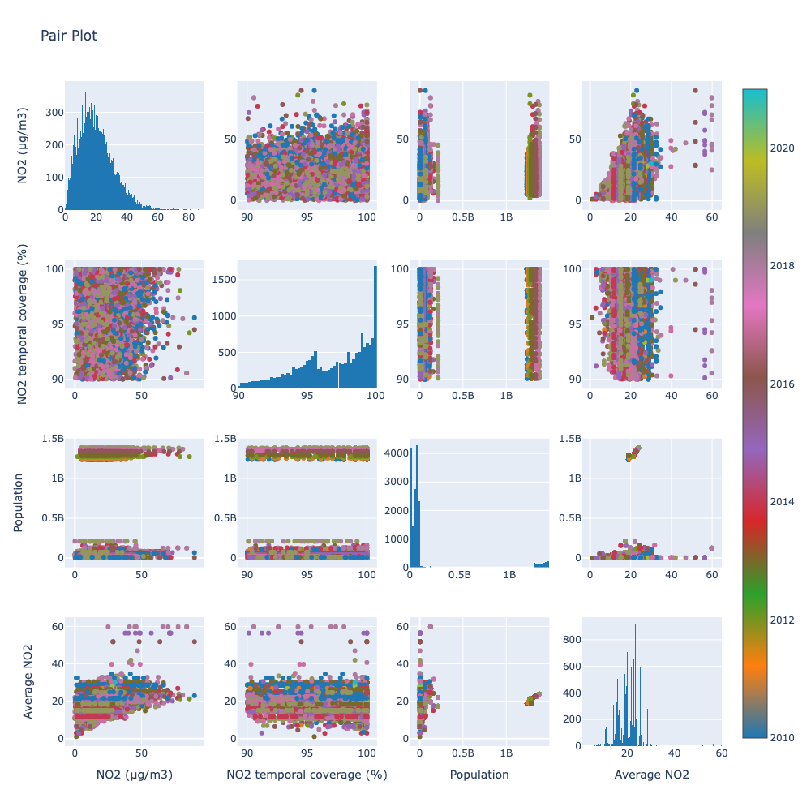

```r
plot1 = 'plot1.png'
display_png(file=plot1)
```

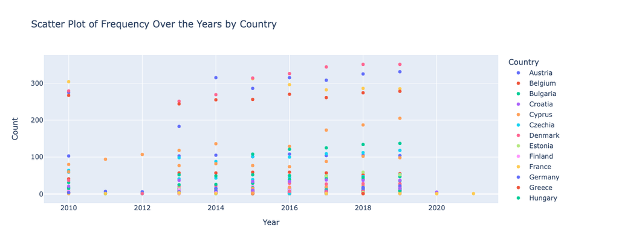

```r
plot2 <- 'plot2.png'
display_png(file=plot2)
```

##### NO<sub>2</sub> Levels By Region and Year

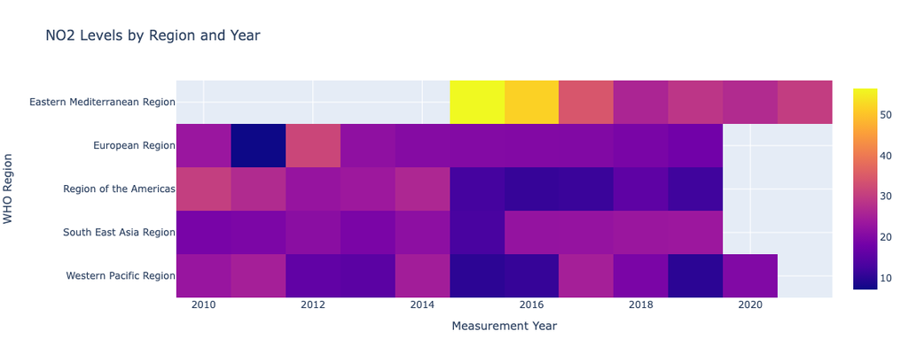

```r
plot3 = 'plot3.png'
display_png(file=plot3)
```

Since the analysis over the countries has been made, understanding the relationship between the different regions (i.e Eastern Mediterranean Region, European Region, Region of the Americas, South East Asia Region, and Western Pacific Region) and years in which NO<sub>2</sub> levels (µg/m3) were measured in those regions is important too. The legend on the right of the graph indicates the level of average NO<sub>2</sub> levels (µg/m3) in that region. Yellow color indicates highest NO<sub>2</sub> levels (µg/m3) and violet color indicates lowest NO<sub>2</sub> levels (µg/m3). It can be observed that the Eastern Mediterranean Region has the highest NO<sub>2</sub> levels (µg/m3) in the year 2015 (indicated by yellow color) and decreases gradually over the years. On the other hand, the Region of the Americas is shown to have the lowest NO<sub>2</sub> levels (µg/m3) (indicated by violet color). The blanks in the plot indicate that there is missing data in the dataset, which highlights the importance of choosing a basal parameter of either a country/region/city or year.

##### Boxplot NO<sub>2</sub> Levels by Region

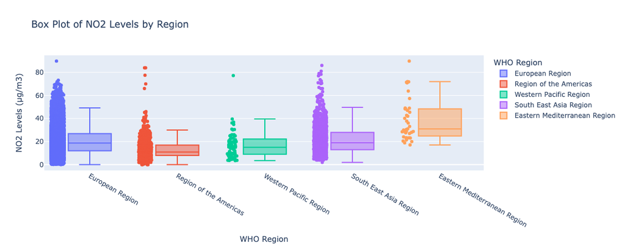

```r
plot4 = 'plot4.png'
display_png(file=plot4)
```

##### NO<sub>2</sub> Levels by City and Year in the European Region

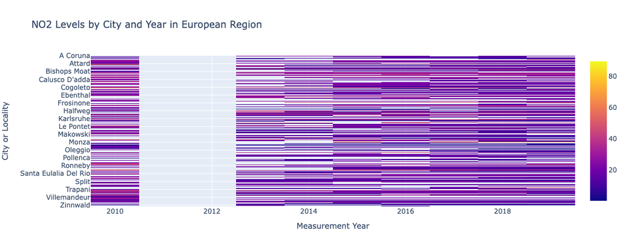

```r
plot5 = 'plot5.png'
display_png(file=plot5)
```

The above graph shows the relationship between the NO<sub>2</sub> levels in different cities in the European Region and years in which NO<sub>2</sub> levels (µg/m3) were measured. The legend on the right of the graph indicates the level of average NO<sub>2</sub> levels (µg/m3) in that region. Yellow color indicates highest NO<sub>2</sub> levels (µg/m3) and violet color indicates lowest NO<sub>2</sub> levels (µg/m3). As observed in the above plot, there is no data available for the NO<sub>2</sub> levels in these cities for the years 2011 and 2012. Also, the blank spaces indicate that there is missing data for several cities over the years.

##### NO<sub>2</sub> Levels by City and Year in the South East Asia Region

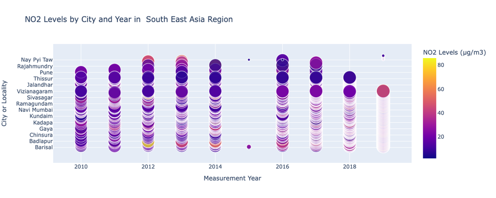

```r
plot6 = 'plot6.png'
display_png(file=plot6)
```

##### Frequency of Each Combination of Year and Country

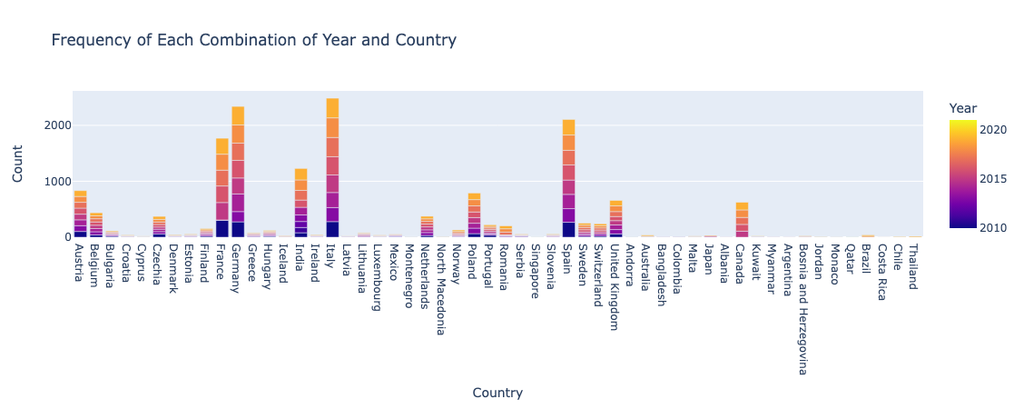

```r
plot7 = 'plot7.png'
display_png(file=plot7)
```

The above plot indicates the number of data points (Average NO<sub>2</sub> levels) that for each particular country. The color indicates the year in which that particular country’s NO<sub>2</sub> levels are measured. The most recent measured countries are indicated by yellow colors whereas the old records are indicated by violet color. As we can observe, the maximum number of data points are available for countries in the European Region like France, Germany, Italy, Spain, etc. followed by India. We can also observe that there is very little data available for countries like Chile, Qatar, Cyprus, Thailand, etc. This indicates that the dataset is biased and unbalanced.

```r
head(merged_df)
```

A data.frame: 6 × 8

|  | ISO3 <chr> | WHO.Country.Name <chr> | Measurement.Year <int> | WHO.Region <chr> | City.or.Locality <chr> | NO2....g.m3. <dbl> | NO2.temporal.coverage.... <dbl> | Population <dbl> |
| --- | --- | --- | --- | --- | --- | --- | --- | --- |
| 1 | ALB | Albania | 2015 | European Region | Elbasan | 23.96 | 97.85388 | 2880703 |
| 2 | ALB | Albania | 2016 | European Region | Elbasan | 26.26 | 96.04964 | 2876101 |
| 3 | AND | Andorra | 2012 | European Region | Escaldes-Engordany | 31.64 | 100.00000 | 71013 |
| 4 | AND | Andorra | 2014 | European Region | Escaldes-Engordany | 27.62 | 100.00000 | 71621 |
| 5 | AND | Andorra | 2015 | European Region | Escaldes-Engordany | 26.65 | 94.55479 | 71746 |
| 6 | AND | Andorra | 2016 | European Region | Escaldes-Engordany | 26.98 | 94.96812 | 72540 |

## Methodology

### T test

When two independent groups have different variances and unequal sample sizes, a statistical test called the Welch t-test, also called the Welch’s unequal variances t-test, is used to compare the means of the two groups. It is a development of the conventional Student’s t-test, which counts on the two groups’ variances being equal.

Usually the hypothesis is formulated for this, where

$H_0$= The means of the output are equal

$H_1$= The means of the output are not equal (You can specify ‘greater’ than or ‘less’ than too)

The test statistic for the Welch t-test is calculated as:

$$t = \frac{\bar{X}_1 - \bar{X}_2}{\sqrt{\frac{s_1^2}{n_1} + \frac{s_2^2}{n_2}}}$$

where $(\bar{X}_1, \bar{X}_2)$ are the sample means, $(s_1^2, s_2^2)$ are the sample variances, and $(n_1, n_2)$ are the sample sizes of the two groups.

The degrees of freedom for the Welch t-test are calculated using the Welch-Satterthwaite equation:
$$\text{df} \approx \frac{\left(\frac{s_1^2}{n_1} + \frac{s_2^2}{n_2}\right)^2}{\frac{\left(\frac{s_1^2}{n_1}\right)^2}{n_1 - 1} + \frac{\left(\frac{s_2^2}{n_2}\right)^2}{n_2 - 1}}$$

The test statistic calculated is then calculated on basis of which one either rejects or accepts the null hypothesis.

The Welch t-test makes the assumption that data is measured on an interval or ratio scale, and that the populations from which samples are taken have a roughly normal distribution. It is also assumed that random sampling, independence of observations, and homogeneity of variances within groups exist. Although the test is resistant to deviations from normalcy and unequal variances, the outcomes could be affected by extreme deviations. When comparing the means of independent groups with unequal variances, it works well. When variances between groups are not equal, the Welch t-test performs better than the Student’s t-test. Without assuming equal variances, it yields accurate results, especially in small sample sizes. Because of this, it is a strong option for comparing means in situations where the Student’s t-test may not be as trustworthy. (Duke University, n.d.; Zach, 2019; Glen, n.d.)

### Chi Square Test

The chi-square test of independence evaluates if two categorical variables significantly correlate with one another. In a contingency table, the observed and expected frequencies are compared as part of the test. As part of the test, a contingency table showing the observed frequencies of the variables’ joint occurrences must be created. On the presumption that the variables are independent, expected frequencies are computed. Next, the chi-square statistic is calculated to determine how much the observed and expected frequencies differ from one another. A greater departure from independence is indicated by a higher chi-square value.

To calculate the chi-square test of independance, you set up the null and the alternative hypothesis first where

$H_0$ : There is absence of significant association between the two variables

$H_1$ : There is presence of significant association between the two variables

The contingency table looks like this:

$$\begin{array}{cccccc}
& \text{Category 1} & \text{Category 2} & \ldots & \text{Category j} & \text{Total} \\
\text{Group A} & O_{11} & O_{12} & \ldots & O_{1j} & R_1 \\
\text{Group B} & O_{21} & O_{22} & \ldots & O_{2j} & R_2 \\
\vdots & \vdots & \vdots & \vdots & \vdots & \vdots \\
\text{Group i} & O_{i1} & O_{i2} & \ldots & O_{ij} & R_i \\
\text{Total} & C_1 & C_2 & \ldots & C_j & N \\
\end{array}$$

The expected frequencies are calculated using;

$$E_{ij} = \frac{\text{Sum of row } i \times \text{Sum of column } j}{\text{Grand total}}$$

The chi-square is calculated using:

$$\chi^2 = \sum_{i=1}^{r} \sum_{j=1}^{c} \frac{(O_{ij} - E_{ij})^2}{E_{ij}}$$

where $r$ is the number of rows and $c$ is the number of columns

The degrees of freedom is calculated using:

$$df = (r-1) \cdot (c-1)$$

The null hypothesis is rejected or accepted if the calculated chi-square statistic is less than 0.05 after comparing it to the critical value from the chi-square distribution table with df degrees of freedom.

The chi-square test of independence relies on the assumptions of mutually exclusive categories, random sampling, and categorical data. For results that can be trusted, a sufficient sample size is needed. To ensure the validity of the test results, the test also assumes the independence of observations and that the expected frequency in each cell is not too low. (Statistics Solutions, n.d.; Penn State World Campus, n.d.; University of Utah, n.d.)

### Bootstrapping

A statistical technique called bootstrapping generates numerous simulated samples by resampling a single dataset. With a variety of sample statistics, this procedure enables one to compute standard errors, creating confidence intervals, and carrying out the hypothesis testing. Known for being more widely applicable and easier to comprehend than traditional hypothesis testing techniques, bootstrap methods are an alternative. This approach is especially useful when sample sizes are constrained or when it is difficult to determine the underlying statistical properties analytically.

In order to bootstrap a distribution, multiple datasets of the same size as the original sample are created, a selected statistic of interest is determined for each dataset, and a distribution is then built using the resampled statistics. By acting as a stand-in for the statistic’s sampling variability, this distribution makes it easier to estimate confidence intervals and conduct hypothesis testing. Next, bias can be computed from both the boostrapped sample and the original sample to determine which one performs better, based on the user-defined question.

Compared to parametric methods, boostrapping has the advantage of requiring fewer distributional assumptions; however, it still relies on the assumption that the observed data accurately represents the underlying population distribution. Additionally, it relies on the randomness of the sampling process and the independence of observations among samples to produce accurate and impartial results. (Hickman, 2023; University of Washington, n.d.)

# Statistical Testing

## Test 1: Did South East Asia Region have more NO<sub>2</sub> (µg/m<sup>3</sup>) emissions than the European Region in 2019?

To compare the average NO<sub>2</sub> (µg/m<sup>3</sup>) in the South East Asia Region compared to the European Region, a Welch Two Sample t-test is performed. In preparation for t-test, the assumptions of the test are assessed before comparing the appropriate variables. First, each observation is assumed to be independent of each observation in the sample. Each region included NO<sub>2</sub> (µg/m<sup>3</sup>) observations for each city in each respective region in the year 2019. Second, each city is assumed to be randomly sampled in the dataset. Third, in this subset, the number of observations for each region had the best balance compared to other years and other regions. The South East Asia Region and European Region has the greatest number of samples in 2019. Finally, the data is reviewed for normality (Statology, 2021).

```r
library(dplyr)
df <- read.csv('data_final.csv')
df1 <- subset(df, select=c(Measurement.Year, WHO.Country.Name))
df2 <- df1[order(df1$Measurement.Year), ]
table <- table(df1)

# Create a new data frame with counts for each combination of Year and Country
count_df <- df1 %>%
  group_by(Measurement.Year, WHO.Country.Name) %>%
  summarize(Frequency = n())

colnames(df)[colnames(df) == "NO2....g.m3."] <- "NO2"
colnames(df)[colnames(df) == "NO2.temporal.coverage...."] <- "NO2.temporal.coverage"
#print(head(df))

df_region <- subset(df, select=c(Measurement.Year, WHO.Region))
```

An important criterion in t-test is that the compared samples should have similar sample sizes. From the clean dataset, a table is created below to count the number of samples in each region by each year. Additionally, another table is created to review the number of samples in each country by each year. Due to the limitations in the sample sizes of each WHO Region, the regions with the highest frequencies are selected for analysis. However, whilst selecting the sample sizes for the Europen Region and South East Asia Region in terms of NO<sub>2</sub> (µg/m<sup>3</sup>), the sample sizes are shown to be different, due to which Welch T-test is used.

```r
# Create a new data frame with counts for each combination of Year and Country
df_region <- df_region %>%
  group_by(Measurement.Year, WHO.Region) %>%
  summarize(Frequency = n())
df_region <- df_region[df_region$Measurement.Year==2019,]
# Display the resulting data frame
print(df_region)
```

```
# A tibble: 5 x 3
# Groups:   Measurement.Year [1]
  Measurement.Year WHO.Region                   Frequency
             <int> <chr>                            <int>
1             2019 Eastern Mediterranean Region         7
2             2019 European Region                   2047
3             2019 Region of the Americas             168
4             2019 South East Asia Region             220
5             2019 Western Pacific Region              20
```

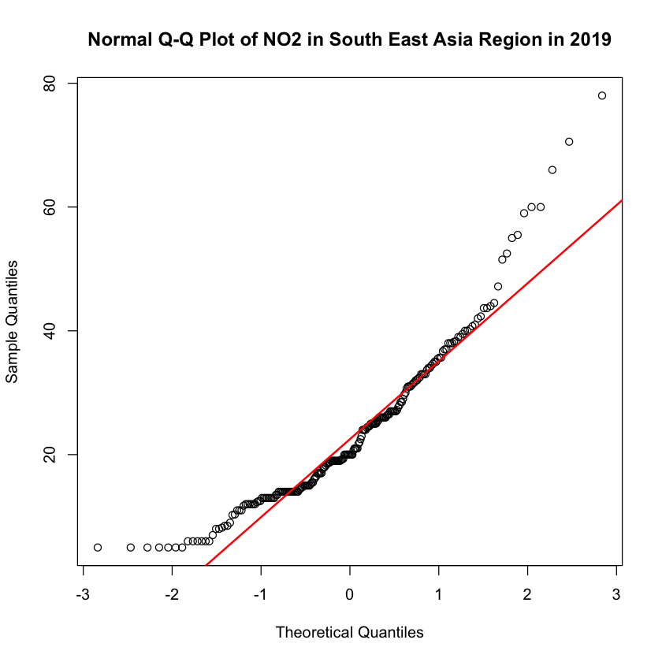

```r
df_SEA_2019 <- df$NO2[df$WHO.Region=="South East Asia Region" &
                                df$Measurement.Year=="2019"]

qqnorm(df_SEA_2019, main="Normal Q-Q Plot of NO2 in South East Asia Region in 2019")
qqline(df_SEA_2019, col = "red", lwd = 2)
```

[figure not shown]

```r
df_EUR_2019 <- df$NO2[df$WHO.Region=="European Region" &
                                df$Measurement.Year=="2019"]

qqnorm(df_SEA_2019, main="Normal Q-Q Plot of NO2 in European Region in 2019")
qqline(df_SEA_2019, col = "blue", lwd = 2)
```

For the statistical testing, the following are null hypothesis and alternative hypothesis using Welch Two Sample t-test

$H_0$: The NO<sub>2</sub> (µg/m<sup>3</sup>) emissions in the South East Asia Region and European Region are similar.

$H_1$: The NO<sub>2</sub> (µg/m<sup>3</sup>) emissions in the South East Asia Region is greater than in the European Region.

```r
df2019 <- df[df$Measurement.Year==2019, ]

sea2 <- subset(df2019, select=NO2,
                      subset=WHO.Region=="South East Asia Region", drop=T)

eur2  <- subset(df2019, select=NO2,
                      subset=WHO.Region=="European Region", drop=T)

t.test(sea2, eur2, alt="greater")
```

```
    Welch Two Sample t-test

data:  sea2 and eur2
t = 6.1356, df = 246.22, p-value = 1.682e-09
alternative hypothesis: true difference in means is greater than 0
95 percent confidence interval:
 4.023139      Inf
sample estimates:
mean of x mean of y
 23.53045  18.02611
```

Conclusion: p-value was less than 0.05, which rejects the null hypothesis

## Test 2.1: Does France have less NO<sub>2</sub> (µg/m<sup>3</sup>) emissions in 2016 than in 2010?

Given that South East Asian has greater NO<sub>2</sub> (µg/m<sup>3</sup>) emissions than Europe, additional testing was performed on France that belongs to the European Region and India from the South East Asian Region

```r
count_df_france <- count_df[count_df$WHO.Country.Name=="France",]
print(count_df_france)
```

```
# A tibble: 7 x 3
# Groups:   Measurement.Year [7]
  Measurement.Year WHO.Country.Name Frequency
             <int> <chr>                <int>
1             2010 France                 304
2             2014 France                   4
3             2015 France                 312
4             2016 France                 296
5             2017 France                 282
6             2018 France                 286
7             2019 France                 285
```

Using the two-sample boostrap test for the ratio of means of NO<sub>2</sub> (µg/m<sup>3</sup>), the null hypothesis and alternative hypothesis are:

$H_0$: France did not decrease NO<sub>2</sub> (µg/m<sup>3</sup>) emissions in 2016 compared to 2010.

$H_1$: France did decrease NO<sub>2</sub> (µg/m<sup>3</sup>) emissions in 2016 compared to 2010.

```r
df_france <- df[df$WHO.Country.Name=="France", ]

france2010 <- subset(df_france, select=NO2,
                      subset=Measurement.Year=="2010", drop=T)

france2016  <- subset(df_france, select=NO2,
                      subset=Measurement.Year=="2016", drop=T)

t.test(france2016, france2010, alt="less")
```

```
    Welch Two Sample t-test

data:  france2016 and france2010
t = -4.3778, df = 597.82, p-value = 7.075e-06
alternative hypothesis: true difference in means is less than 0
95 percent confidence interval:
      -Inf -2.275993
sample estimates:
mean of x mean of y
 19.30578  22.95500
```

```r
df_france <- df[df$WHO.Country.Name=="France", ]
df_france_2010 <- df_france[df_france$Measurement.Year == "2010", ]
df_france_2016 <- df_france[df_france$Measurement.Year == "2016", ]
N <- 100000

ratiomeans<- numeric(N)

for (i in 1:N)
{
  fr_sample_2010 <- sample(df_france_2010$NO2[df_france_2010$Measurement.Year == '2010'], length(df_france_2010), replace = TRUE)
  fr_sample_2016 <- sample(df_france_2016$NO2[df_france_2016$Measurement.Year == '2016'], length(df_france_2016), replace = TRUE)
  ratiomeans[i] <- mean(fr_sample_2010)/mean(fr_sample_2016)
}

quantile(ratiomeans, c(0.025, 0.975))

fr_mean_2010 <- mean(df_france_2010$NO2[df_france_2010$Measurement.Year == '2010'])
fr_mean_2016 <- mean(df_france_2016$NO2[df_france_2016$Measurement.Year == '2016'])
ratio_actual <- fr_mean_2010/fr_mean_2016
bias= round(mean(ratiomeans)-mean(ratio_actual), digits = 3) #estimated bias

print(paste("The estimated bias is", bias))
```

**2.5%**

0.783456920811503

**97.5%**

1.83791169131899

```
[1] "The estimated bias is 0.031"
```

Conclusion: Yes, France has decreased their NO<sub>2</sub> (µg/m<sup>3</sup>) emissions in 2016.

## Test 2.2: Did India have greater NO<sub>2</sub> (µg/m<sup>3</sup>) emissions in 2018 than in 2014?

Additional Welsh t-test is performed to assess if India has greater NO<sub>2</sub> (µg/m<sup>3</sup>) in 2018 compared to 2014. The average NO2 emissions in India in 2018 are also compared to the average NO<sub>2</sub> emissions in India in 2014, as the frequencies for them are almost closer to each other, yet significant enough to assess changes.

```r
count_df_india <- count_df[count_df$WHO.Country.Name=="India",]
print(count_df_india)
```

```
# A tibble: 9 x 3
# Groups:   Measurement.Year [9]
  Measurement.Year WHO.Country.Name Frequency
             <int> <chr>                <int>
1             2010 India                   80
2             2011 India                   94
3             2012 India                  107
4             2013 India                  118
5             2014 India                  136
6             2016 India                  129
7             2017 India                  173
8             2018 India                  187
9             2019 India                  205
```

Using Welch Two Sample t-test, the null hypothesis and alternative hypothesis are:

$H_0$: India did not increase NO<sub>2</sub> (µg/m<sup>3</sup>) emissions in 2018 compared to 2014.

$H_1$: India increased NO<sub>2</sub> (µg/m<sup>3</sup>) emissions in 2018 compared to 2014.

```r
df_india <- df[df$WHO.Country.Name=="India", ]

india2014 <- subset(df_india, select=NO2,
                      subset=Measurement.Year==2014, drop=T)

india2018  <- subset(df_india, select=NO2,
                      subset=Measurement.Year==2018, drop=T)

print(t.test(india2018, india2014, alt="greater"))
```

```
    Welch Two Sample t-test

data:  india2018 and india2014
t = 1.0464, df = 268.02, p-value = 0.1482
alternative hypothesis: true difference in means is greater than 0
95 percent confidence interval:
 -0.9638244        Inf
sample estimates:
mean of x mean of y
 23.35289  21.68338
```

Conclusion: The p-value is greater than 0.05, which fails to reject the null hypothesis.

## Test 3: Was global NO<sub>2</sub> dependent on Year?

The new WHO guideline column and the year column meets the required assumption that both variables in the Chi-square test are categorical. Like in t-test, each observation is assumed to be independent. A contingency table is calculated with the number of cities meeting within or above the WHO guidelines for each year. The values in the contingency table are mutually exclusive.

```r
df$WHO.Guideline <- ifelse(df$NO2 >= 41.0, "above", "within")
head(df)
```

A data.frame: 6 × 11

|  | X <int> | WHO.Region <chr> | ISO3 <chr> | WHO.Country.Name <chr> | City.or.Locality <chr> | Measurement.Year <int> | NO2 <dbl> | NO2.temporal.coverage <dbl> | Population <dbl> | Average.NO2 <dbl> | WHO.Guideline <chr> |
| --- | --- | --- | --- | --- | --- | --- | --- | --- | --- | --- | --- |
| 1 | 0 | European Region | ALB | Albania | Elbasan | 2015 | 23.96 | 97.85388 | 2880703 | 23.96 | within |
| 2 | 1 | European Region | ALB | Albania | Elbasan | 2016 | 26.26 | 96.04964 | 2876101 | 26.26 | within |
| 3 | 2 | European Region | AND | Andorra | Escaldes-Engordany | 2012 | 31.64 | 100.00000 | 71013 | 31.64 | within |
| 4 | 3 | European Region | AND | Andorra | Escaldes-Engordany | 2014 | 27.62 | 100.00000 | 71621 | 27.62 | within |
| 5 | 4 | European Region | AND | Andorra | Escaldes-Engordany | 2015 | 26.65 | 94.55479 | 71746 | 26.65 | within |
| 6 | 5 | European Region | AND | Andorra | Escaldes-Engordany | 2016 | 26.98 | 94.96812 | 72540 | 26.98 | within |

To assess if global compliance with recommended NO<sub>2</sub> (µg/m<sup>3</sup>) is dependent on year, Chi-squared test is used.

The null hypothesis and alternative hypothesis are:

$H_0$: The compliance with recommended NO<sub>2</sub> (µg/m<sup>3</sup>) are independent from years. The compliance with recommended NO<sub>2</sub> does not differ between years.

$H_1$: The compliance with recommended NO<sub>2</sub> (µg/m<sup>3</sup>) are dependent on the year. The compliance with recommended NO<sub>2</sub> differs between the years.

```r
df_global <- df[(df$Measurement.Year>=2013 & df$Measurement.Year<=2019),]

# actual
table_year<- table(df_global$Measurement.Year, df_global$WHO.Guideline)
table_year

print(chisq.test(table_year))
```

```
       above within
  2013   119   1347
  2014   111   1520
  2015   103   1869
  2016   118   2056
  2017   104   2149
  2018    91   2317
  2019    53   2409
```

```
    Pearson's Chi-squared test

data:  table_year
X-squared = 94.367, df = 6, p-value < 2.2e-16
```

Additionally, expected values of the contingency table are calculated and compared to the actual values. All expected values of the contingency table are above 50 for all the values. Thus, these criteria confirm the appropriate use of Chi-square test as each value is large enough.

```r
#expected
print(chisq.test(table_year)$expected)
```

```
           above   within
  2013  71.33050 1394.669
  2014  79.35883 1551.641
  2015  95.95072 1876.049
  2016 105.77934 2068.221
  2017 109.62321 2143.377
  2018 117.16497 2290.835
  2019 119.79243 2342.208
```

Conclusion: Therefore, compliance with recommended NO<sub>2</sub> (µg/m<sup>3</sup>) differs between the years.

# Results and Discussion

After performing the Welch Two Sample t-test on average NO<sub>2</sub> (µg/m<sup>3</sup>), the p-value was is less than 0.05. This result supports the alternative hypothesis that NO<sub>2</sub> (µg/m<sup>3</sup>) emissions were greater in the South East Asia Region than in the European Region. This is consistent with previous research that has found a rise in NO<sub>2</sub> (µg/m<sup>3</sup>) in the Asian Region (Jion et al., 2023).

To determine if NO<sub>2</sub> (µg/m<sup>3</sup>) is dependent on year, Chi-square test is performed. The p-value was much less than 0.05. This result supports the alternative hypothesis. The compliance with recommended NO<sub>2</sub> (µg/m<sup>3</sup>) is dependent on the year. The compliance with recommended NO<sub>2</sub> (µg/m<sup>3</sup>) differs between the years.

# Conclusion

Our study analyzed the levels of NO<sub>2</sub> (µg/m<sup>3</sup>), which is a key indicator of air quality. Using existing data from the WHO Air Quality Database, the data was transformed from a real-world messy format into actionable conclusions and evidence to inform better decision making. The dataset was challenging to analyze because the measurement of NO<sub>2</sub> (µg/m<sup>3</sup>) was not consistent between the many stations that monitor NO<sub>2</sub>. However, using the data available, we were still able to find notable differences in NO<sub>2</sub> (µg/m<sup>3</sup>). The analysis found that NO<sub>2</sub> (µg/m<sup>3</sup>) was greater in the South East Asia Region than in the European Region in 2019, emphasizing the importance of regional disparities in air pollution. However, when examining NO<sub>2</sub> (µg/m<sup>3</sup>) emission in India from 2018 to 2014, we did not observe a change. The differences underscore the importance of policy and government to monitor NO<sub>2</sub>. Better collection and coverage of measured NO<sub>2</sub> in future years can improve the results of the statistical analysis.

Furthermore, our study also explored NO<sub>2</sub> (µg/m<sup>3</sup>) levels in France, showcasing a meaningful reduction in emissions from 2010 to 2016. This finding underscores the potential positive impact of target measures in migrating air pollution as recommended by the WHO.

The analysis also revealed that global NO<sub>2</sub> compliance trends vary between years. This emphasized that adherence to recommended NO<sub>2</sub> levels depended on years. More research can be done to better understand if NO<sub>2</sub> is increasing or decreasing over the years. This research will require statistical methods taught outside the DSAN 5100 course in Probabilistic Modeling and Statistical Computing. However, given the statistical methods and data currently available, these meaningful findings open the doors for new data science questions. These findings reveal the beginning of potential findings that can come from real-world data.

Overall, our research contributes valuable insights into the complexities of air quality dynamics, advocating for ongoing efforts to monitor and address air pollution on both regional and global scales. These findings hold implications for public health and environmental policies, urging a continued focus on sustainable practices to improve air quality for the well-being of communities worldwide.

# References

1. AirNow. (n.d). Title of the specific page. Retrieved from https://www.airnow.gov/ ‌Casquero-Vera, J.A., et al. “Impact of Primary NO2 Emissions at Different Urban Sites
2. Clean Air Asia. (n.d). Title of the specific page. Retrieved from https://cleanairasia.org/ Exceeding the European NO2 Standard Limit.” Science of the Total Environment, vol. 646, Jan. 2019, pp. 1117–1125, https://doi.org/10.1016/j.scitotenv.2018.07.360.
3. Duke University. (n.d). Welch’s T-Test. Retrieved from https://sites.nicholas.duke.edu/statsreview/means/welch/
4. European Environment Agency. (n.d). European Environment Agency. Retrieved http://www.eea.europa.eu/en
5. Glen, S. (n.d). Welch’s Test for Unequal Variances: Definition, Examples. Retrieved Month Day, Year, from https://www.statisticshowto.com/welchs-test-for-unequal-variances/
6. Grice, S., Stedman, J., Kent, A., Hobson, M., Norris, J., Abbott, J., & Cooke, S. (2009). Recent trends and projections of primary NO2 emissions in Europe. Atmospheric Environment, 43(13), 2154–2167. https://doi.org/10.1016/j.atmosenv.2009.01.019
7. Hickman, J. (2023). Bootstrap Sampling. Retrieved from https://jfh.georgetown.domains/dsan5100/slides/W10/notes.html#bootstrap-sampling
8. Jarvis DJ, Adamkiewicz G, Heroux ME, et al. Nitrogen dioxide. In: WHO Guidelines for Indoor Air Quality: Selected Pollutants. Geneva: World Health Organization; 2010. 5. Available from: https://www.ncbi.nlm.nih.gov/books/NBK138707/
9. Jion, Most. M. M. F., Jannat, J. N., Mia, Md. Y., Ali, Md. A., Islam, Md. S., Ibrahim, S. M., Pal, S. C., Islam, A., Sarker, A., Malafaia, G., Bilal, M., & Islam, A. R. M. T. (2023). A critical review and prospect of NO2 and SO2 pollution over Asia: Hotspots, trends, and sources. Science of the Total Environment, 876, 162851. https://doi.org/10.1016/j.scitotenv.2023.162851
10. Kolcava, D., Nguyen, Q., & Bernauer, T. (2019). Does trade liberalization lead to environmental burden shifting in the global economy? Ecological Economics, 163, 98–112. https://doi.org/10.1016/j.ecolecon.2019.05.006
11. Larkin, A., Geddes, J. A., Martin, R. V., Xiao, Q., Liu, Y., Marshall, J. D., Brauer, M., & Hystad, P. (2017). Global Land Use Regression Model for Nitrogen Dioxide Air Pollution. Environmental Science & Technology, 51(12), 6957–6964. https://doi.org/10.1021/acs.est.7b01148
12. Penn State World Campus. (n.d). Lesson 11: The Chi-Square Test. Retrieved from https://online.stat.psu.edu/stat200/lesson/11/11.3
13. Pope, C. A., & Dockery, D. W. (2006). Health Effects of Fine Particulate Air Pollution: Lines that Connect. Journal of the Air & Waste Management Association, 56(6), 709–742. https://doi.org/10.1080/10473289.2006.10464485
14. Statistics Solutions. (n.d). Directory of Statistical Analyses: Chi-Square Test. Retrieved from https://www.statisticssolutions.com/free-resources/directory-of-statistical-analyses/chi-square/#:~:text=The%20degrees%20of%20freedom%20for,null%20hypothesis%20can%20be%20rejected.
15. The Institute for Health Metrics and Evaluation. (2019). Global Burden of Disease (GBD). Www.healthdata.org. https://www.healthdata.org/research-analysis/gbd
16. University of Utah, Department of Sociology. (n.d). Sociology 3112: Chi-Square. Retrieved Month Day, Year, from https://soc.utah.edu/sociology3112/chi-square.php
17. University of Washington. (n.d). Bootstrap Examples. Retrieved from https://courses.washington.edu/matlab1/Bootstrap_examples.html
18. US EPA 1993. Air quality criteria for oxides of nitrogen. Research Triangle Park (NC United States Environmental Protection Agency (EPA/600/891/049aF-cF. 3v).
19. US EPA 1995. Air quality criteria for ozone and related photochemical oxidants. Research Triangle Park (NC United States Environmental Protection Agency (EPA/600/P93/004aF cF.3v).
20. Wang, L., Zhong, B., Vardoulakis, S., Zhang, F., Pilot, E., Li, Y., Yang, L., Wang, W., & Krafft, T. (2016). Air Quality Strategies on Public Health and Health Equity in Europe—A Systematic Review. International Journal of Environmental Research and Public Health, 13(12). https://doi.org/10.3390/ijerph13121196
21. World Bank. (2022). Population, total. Worldbank.org; World Bank Group. https://data.worldbank.org/indicator/SP.POP.TOTL
22. Zach. (2019). Welch’s T-Test: Definition, Formula, Example. Retrieved from https://www.statology.org/welchs-t-test/
23. ZACH. (2019, May 29). Welch’s t-test: When to Use it + Examples. Statology. https://www.statology.org/welchs-t-test/
24. Zach. (2021, March 16). The Four Assumptions Made in a T-Test. Statology. https://www.statology.org/t-test-assumptions/
25. Zach. (2021, August 14). The Four Assumptions of a Chi-Square Test. Statology. https://www.statology.org/chi-square-test-assumptions/